# Demonstration of the Use of `mice` for Imputing Missing Values

James Wagner

12/14/2021

## Load the Data

We will be using the Titanic training data set from Kaggle.com (https://www.kaggle.com/c/titanic/data). Age is missing for some cases.

```r
train <- read.csv("train.csv")
```

## Missing Data Pattern

The first step is to review the missing data pattern. For a relatively small dataset, the mice package includes a function that will plot the missing data. Large datasets might require a different strategy for visualizing missing data. The VIM package is an alternative that will aid in visualization of missing data patterns.

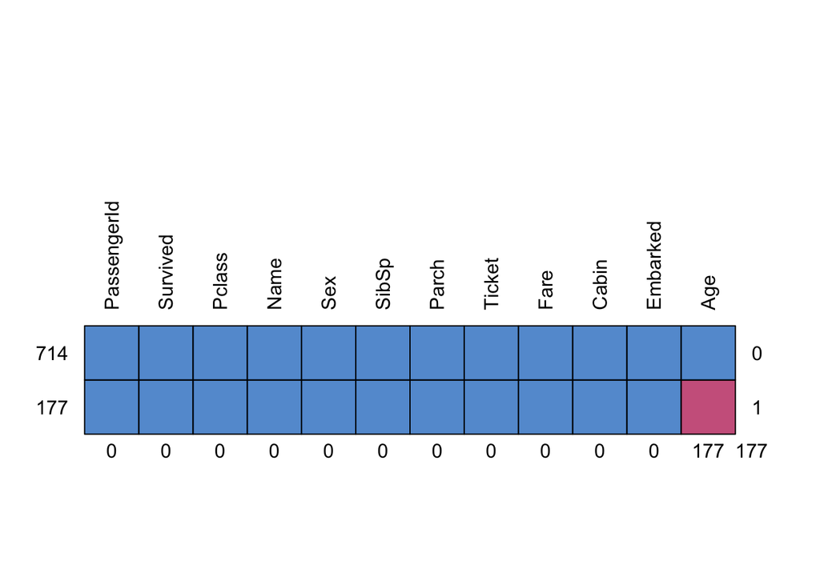

```
##     PassengerId Survived Pclass Name Sex SibSp Parch Ticket Fare Cabin Embarked
## 714           1        1      1    1   1     1     1      1    1     1        1
## 177           1        1      1    1   1     1     1      1    1     1        1
##               0        0      0    0   0     0     0      0    0     0        0
##     Age
## 714   1   0
## 177   0   1
##     177 177
```

```r
md.pattern(train,rotate.names=TRUE)
```

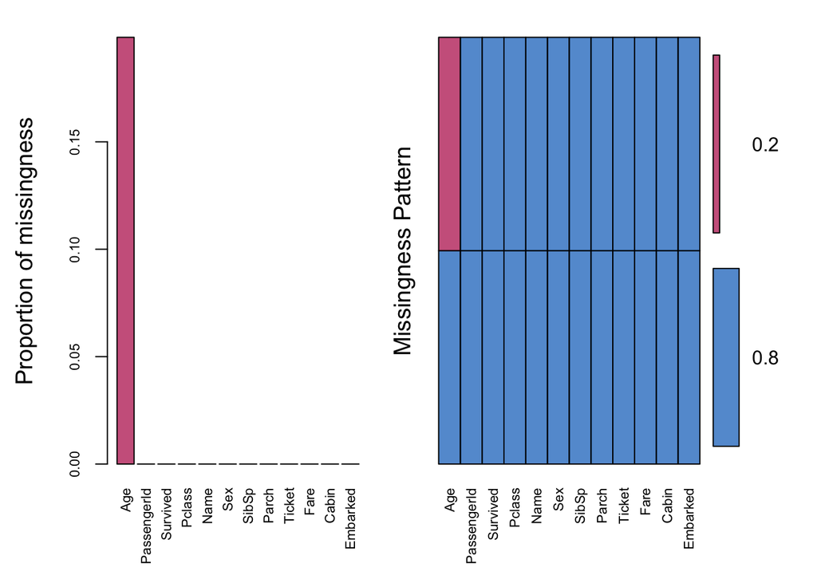

```
##
##  Variables sorted by number of missings:
##     Variable     Count
##          Age 0.1986532
##  PassengerId 0.0000000
##     Survived 0.0000000
##       Pclass 0.0000000
##         Name 0.0000000
##          Sex 0.0000000
##        SibSp 0.0000000
##        Parch 0.0000000
##       Ticket 0.0000000
##         Fare 0.0000000
##        Cabin 0.0000000
##     Embarked 0.0000000
```

```r
train_aggr = aggr(train, col=mdc(1:2), numbers=TRUE, sortVars=TRUE, labels=names(train), cex.axis=.7, gap=3, ylab=c("Proportion of missingness","Missingness Pattern"))
```

In the figure, the red bars indicate where the missing values are. In this case, the pattern is very simple since only one variable has missing values – `Age`. We can also see from the figure on the right that about 20% of the values are missing for this variable.

## Create Imputed Values

The mice package is used to create the imputed values. We remove some variables that aren’t relevant for imputation (e.g. the passenger’s name, train[,-c(1,4,9,11,13)]). The number of imputed values is set to 5 (m=5). As a rule of thumb, the larger the rate of missing data, the larger the number of imputations that are necessary to insure reliable imputed means. In this example, we set m=5 as demonstration. In practice, a larger number of imputations would be more reliable in most situations. We ask for the maximum number of iterations to be 50 (maxit=50). The imputation models are run across all variables with missing values, substituting imputed values in iterations after the maximum number of iterations have been run. The method of imputation is predictive mean matching (meth=‘pmm’). We set a seed so that the same imputations will be achieved each time we run this program. Finally, we turn off the printing of updates to the console (print=FALSE). Turning on those updates may be helpful when attempting to diagnose issues.

```r
#Create a missing data indicator
train$ry <- ifelse(is.na(train$Age), 1, 0)
train.impute <- mice(train[,-c(1,4,9,11,13)],m=5,maxit=50,meth='pmm',seed=500,print=FALSE)
```

## Review the Imputed Values

It is important to review the imputed values. This step will insure that the imputed values are plausible and uncover potential problems with the model or other specifications used in the creation of the imputations.

The following are a print of the list of imputed values, a density plot showing the distribution of each of the 5 sets of imputed values, the mean of the observed data, and the mean of each of the fully-imputed datasets. If the imputations lead to large changes in the estimated mean, it would be good to understand why this has occured.

```r
train.impute$imp$Age[1:10,]#Show only first 10 cases
```

```
##     1  2  3    4  5
## 6  20 28 21 19.0 18
## 18 39 19 25 34.0 19
## 20 54 24 27 45.0 48
## 27 20 11 19 21.0 18
## 29 26 48 25 32.0 20
## 30 37 11 11 11.0 41
## 32 31 39 48 32.5 14
## 33 26 25 27 32.0 22
## 37 24 16 24 26.0 48
## 43 20 11 17 28.5 13
```

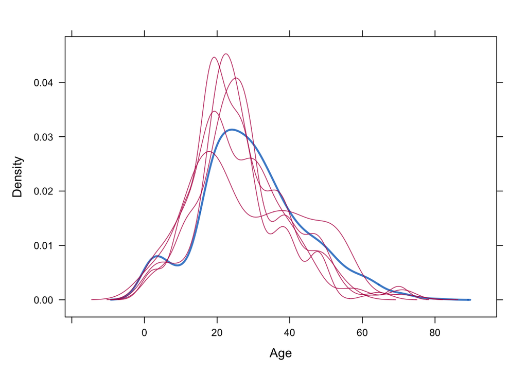

```r
densityplot(train.impute)
```

```r
mean(train$Age,na.rm=TRUE)
```

```
## [1] 29.69912
```

```r
summary(with(train.impute, mean(Age)))
```

```
## # A tibble: 5 × 1
##       x
##   <dbl>
## 1  29.1
## 2  29.2
## 3  28.7
## 4  28.8
## 5  29.5
```

## Estimation

Now we can create a fully-imputed data frame (imp1). Or, we can use the appropriate multiple imputation estimation procedures. In this example, we are using logistic regression to estimate the probability of surviving the sinking of the Titanic.

The multiple imputation estimates return the average within (`ubar`) and between imputation (`b`) variance. These are combined into a single estimate of the variance (`t`). The `riv` is the relative increase in variance due to missing data. `lambda` is the proportion of variance due to missing data. The `fmi` is the fraction of missing information. A simpler form of the output is also available.

```r
imp1<-complete(train.impute,action=1L)
fit1 <- with(train.impute, glm(Survived ~ Pclass + Sex + Age + Fare,family=binomial), print=F)
fit1.est<-pool(fit1)
fit1.est
```

```
## Class: mipo    m = 5
##          term m      estimate         ubar            b            t dfcom
## 1 (Intercept) 5  4.6285317706 2.677795e-01 1.032976e-01 3.917366e-01   886
## 2      Pclass 5 -1.1877808371 1.981175e-02 3.643615e-03 2.418409e-02   886
## 3     Sexmale 5 -2.6043111779 3.505927e-02 4.696173e-04 3.562282e-02   886
## 4         Age 5 -0.0294131710 4.791204e-05 4.052992e-05 9.654795e-05   886
## 5        Fare 5  0.0003153946 4.154667e-06 5.848249e-08 4.224846e-06   886
##          df        riv     lambda        fmi
## 1  37.47170 0.46290742 0.31642974 0.35020990
## 2 104.68479 0.22069424 0.18079404 0.19600893
## 3 825.10870 0.01607394 0.01581966 0.01819659
## 4  15.21602 1.01510814 0.50374872 0.55823387
## 5 820.14098 0.01689160 0.01661102 0.01900038
```

```r
summary(fit1.est)
```

```
##          term      estimate   std.error   statistic        df      p.value
## 1 (Intercept)  4.6285317706 0.625888614   7.3951366  37.47170 7.862919e-09
## 2      Pclass -1.1877808371 0.155512334  -7.6378562 104.68479 1.092486e-11
## 3     Sexmale -2.6043111779 0.188740073 -13.7984008 825.10870 4.022521e-39
## 4         Age -0.0294131710 0.009825881  -2.9934384  15.21602 8.979414e-03
## 5        Fare  0.0003153946 0.002055443   0.1534436 820.14098 8.780862e-01
```

```r
#For comparison, the same model on observed data only
obs.model<-glm(Survived ~ Pclass + Sex + Age + Fare,data=train,family=binomial)
summary(obs.model)
```

```
##
## Call:
## glm(formula = Survived ~ Pclass + Sex + Age + Fare, family = binomial,
##     data = train)
##
## Coefficients:
##               Estimate Std. Error z value Pr(>|z|)
## (Intercept)  4.9880403  0.5721894   8.717  < 2e-16 ***
## Pclass      -1.2697410  0.1586252  -8.005 1.20e-15 ***
## Sexmale     -2.5181969  0.2078562 -12.115  < 2e-16 ***
## Age         -0.0367073  0.0076795  -4.780 1.75e-06 ***
## Fare         0.0005373  0.0021821   0.246    0.805
## ---
## Signif. codes:  0 '***' 0.001 '**' 0.01 '*' 0.05 '.' 0.1 ' ' 1
##
## (Dispersion parameter for binomial family taken to be 1)
##
##     Null deviance: 964.52  on 713  degrees of freedom
## Residual deviance: 647.23  on 709  degrees of freedom
##   (177 observations deleted due to missingness)
## AIC: 657.23
##
## Number of Fisher Scoring iterations: 5
```